# Namibia DHS

Caroline Owens

2023-03-23

### DHS Namibia— Assessing wealth, status, and mental well-being using Namibia DHS data

##### Assess Wealth Dimensions against the DHS Wealth Index (HV271)

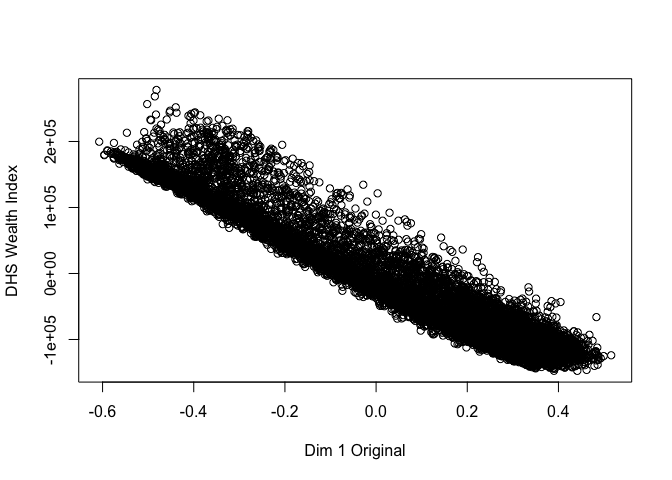

```r
#################################
### Anchor and Check Results ####
#################################

#### Here, we check our created dimension 1 against the pre-created DHS wealth index
plot(hhnamibia_wealthdim$Dim.1, hhnamibia_wealthdim$HV271, xlab="Dim 1 Original", ylab="DHS Wealth Index")
```

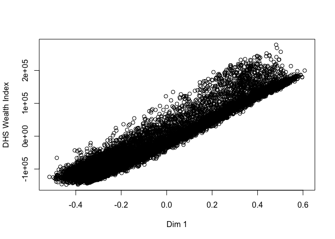

```r
#reverse Dim 1
hhnamibia_wealthdim$Dim.1 <- -1*hhnamibia_wealthdim$Dim.1
plot(hhnamibia_wealthdim$Dim.1, hhnamibia_wealthdim$HV271, xlab="Dim 1", ylab="DHS Wealth Index")
```

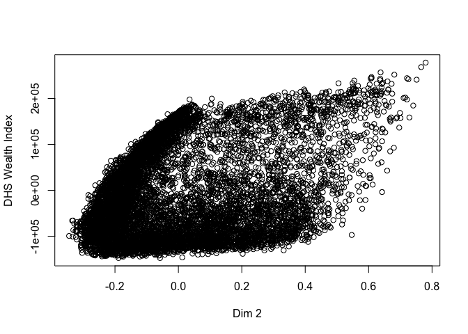

[figure not shown]

```r
plot(hhnamibia_wealthdim$Dim.2, hhnamibia_wealthdim$HV271, xlab="Dim 2", ylab="DHS Wealth Index")
```

##### Assess means of key variables and dimensions 1 and 2 to affirm anchoring and examine differences in assets across the landscape of wealth in Namibia.

```
## # A tibble: 3 × 4
##   AnyCows meandim1 meandim2  nobs
##     <dbl>    <dbl>    <dbl> <int>
## 1       0   0.0404   -0.108  6757
## 2       1  -0.108     0.256  2951
## 3      NA   0.241     0.290     4
```

```
## # A tibble: 3 × 4
##   AnyChickens meandim1 meandim2  nobs
##         <dbl>    <dbl>    <dbl> <int>
## 1           0   0.0915  -0.0997  6031
## 2           1  -0.162    0.170   3676
## 3          NA   0.114    0.324      5
```

```
## # A tibble: 2 × 4
##   AnyLand meandim1 meandim2  nobs
##     <dbl>    <dbl>    <dbl> <int>
## 1       0   0.0905  -0.0904  5734
## 2       1  -0.142    0.136   3978
```

```
## # A tibble: 2 × 4
##   Urban meandim1 meandim2  nobs
##   <dbl>    <dbl>    <dbl> <int>
## 1     0   -0.176   0.0549  5020
## 2     1    0.179  -0.0535  4692
```

```
## # A tibble: 2 × 4
##   BankAccount meandim1 meandim2  nobs
##         <dbl>    <dbl>    <dbl> <int>
## 1           0  -0.215   -0.0725  2561
## 2           1   0.0707   0.0294  7151
```

```
## # A tibble: 2 × 4
##   Computer meandim1 meandim2  nobs
##      <dbl>    <dbl>    <dbl> <int>
## 1        0  -0.0897  -0.0138  7893
## 2        1   0.364    0.0732  1819
```

```
## # A tibble: 2 × 4
##      TV meandim1 meandim2  nobs
##   <dbl>    <dbl>    <dbl> <int>
## 1     0   -0.200  -0.0185  5484
## 2     1    0.248   0.0297  4228
```

##### Expanding on assessment of means we will now assess correlations between dimensions and these variables.

```
## [1] -0.3988543
```

```
## [1] 0.519735
```

```
## [1] -0.2385174
```

```
## [1] 0.7801348
```

```
## [1] -0.4302005
```

```
## [1] 0.6089328
```

```
## [1] 0.6183913
```

```
## [1] -0.2523585
```

```
## [1] 0.4394747
```

```
## [1] 0.2091677
```

```
## [1] 0.6186953
```

```
## [1] 0.1580558
```

```
## [1] 0.7757229
```

```
## [1] 0.1112578
```

##### Merge and clean data- note that, among those who report days of low energy and little energy, peak around 1 week (cognitive ease of 1 week?). Distributions are relatively similar across the sexes.

```r
###########################
### Merge into womens file ####
###########################

vars_to_keep_households <- c("HV000", "HV001", "HV002", "Dim.1", "Dim.2", "HV271")
hh_wealth <- hhnamibia_wealthdim[vars_to_keep_households]




# Mental health variables are as follows: S1010S = Times you see or hear things, S1010T = Felt worthless, S1010U = Felt little interest, S1010V = Felt low energy/sad
# For two of the variables there are also number of days variables: S1010UN = # of days felt little interest in past two weeks, S1010VN = # of days felt low energy/sad in past two weeks


# Explore the mental health variables for women
womennamibia %>% count(S1010S) #See or hear things
```

```
##   S1010S    n
## 1     No 8589
## 2    Yes 1422
## 3   <NA>    7
```

```r
womennamibia %>% count(S1010T) # felt worthless
```

```
##   S1010T    n
## 1     No 8659
## 2    Yes 1347
## 3   <NA>   12
```

```r
womennamibia %>% count(S1010U) #felt little interest
```

```
##               S1010U    n
## 1                 No 7804
## 2                Yes 2157
## 3 Dont know/not sure   52
## 4               <NA>    5
```

```r
womennamibia %>% count(S1010UN) # of days felt little interest
```

```
##    S1010UN    n
## 1        1  518
## 2        2  706
## 3        3  379
## 4        4  110
## 5        5   82
## 6        6   13
## 7        7  254
## 8        8    8
## 9        9    4
## 10      10   14
## 11      12    8
## 12      13    1
## 13      14   55
## 14      NA 7866
```

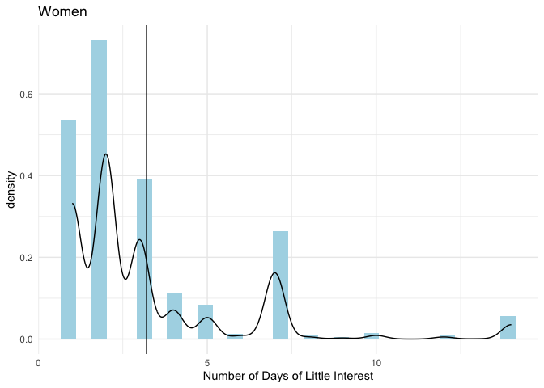

```r
# Plot distribution
#### Density plot/histogram # of Days Little Interest
womennamibia %>%
  ggplot(aes(x=S1010UN)) +
  geom_histogram(aes(y=..density..), fill = "lightblue") +
  geom_density(alpha = .2) +
  geom_vline(aes(xintercept=mean(S1010UN, na.rm = T)),
             color="black") +
  xlab("Number of Days of Little Interest") + ggtitle("Women") +
  theme_minimal()
```

```r
womennamibia %>% count(S1010V) #felt low energy & sad
```

```
##               S1010V    n
## 1                 No 7679
## 2                Yes 2299
## 3 Dont know/not sure   36
## 4               <NA>    4
```

```r
womennamibia %>% count(S1010VN) # of days felt low energy/")
```

```
##    S1010VN    n
## 1        1  616
## 2        2  654
## 3        3  379
## 4        4  156
## 5        5   74
## 6        6   17
## 7        7  284
## 8        8   11
## 9        9    3
## 10      10   14
## 11      11    1
## 12      12   11
## 13      13    2
## 14      14   72
## 15      NA 7724
```

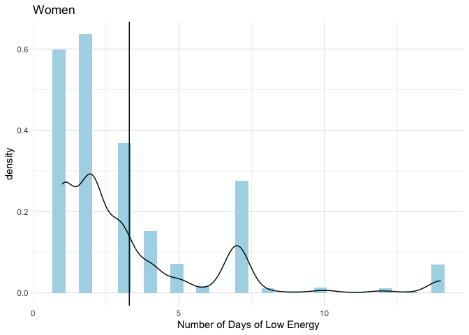

```r
#### Density plot/histogram # of Days Low Energy
womennamibia %>%
  ggplot(aes(x=S1010VN)) +
  geom_histogram(aes(y=..density..), fill = "lightblue") +
  geom_density(alpha = .2) +
  geom_vline(aes(xintercept=mean(S1010VN, na.rm = T)),
             color="black") +
  xlab("Number of Days of Low Energy") + ggtitle("Women") +
  theme_minimal()
```

```r
table(womennamibia$S1010U, womennamibia$S1010UN)
```

```
##
##                        1   2   3   4   5   6   7   8   9  10  12  13  14
##   No                   0   0   0   0   0   0   0   0   0   0   0   0   0
##   Yes                518 706 379 110  82  13 254   8   4  14   8   1  55
##   Dont know/not sure   0   0   0   0   0   0   0   0   0   0   0   0   0
```

```r
#explore mental health for men SM813Q", "SM813R", "SM813S", "SM813SN",  "SM813T", "SM813TN"

#namibia_all_men
mennamibia %>%  count(SM813Q) #See or hear things
```

```
##   SM813Q    n
## 1     No 3985
## 2    Yes  491
## 3   <NA>    5
```

```r
mennamibia %>%  count(SM813R)  #felt worthless
```

```
##   SM813R    n
## 1     No 4074
## 2    Yes  331
## 3   <NA>   76
```

```r
mennamibia %>%  count(SM813S) #felt little interest
```

```
##               SM813S    n
## 1                 No 3888
## 2                Yes  553
## 3 Dont know/not sure   35
## 4               <NA>    5
```

```r
mennamibia %>%  count(SM813SN) # of days felt little interest
```

```
##    SM813SN    n
## 1        1  148
## 2        2  186
## 3        3   83
## 4        4   40
## 5        5   18
## 6        6    9
## 7        7   47
## 8        8    3
## 9        9    1
## 10      10    4
## 11      11    1
## 12      13    1
## 13      14   12
## 14      NA 3928
```

```r
mennamibia %>%  count(SM813T)  #felt low energy & sad
```

```
##               SM813T    n
## 1                 No 3882
## 2                Yes  558
## 3 Dont know/not sure   35
## 4               <NA>    6
```

```r
mennamibia %>%  count(SM813TN) ## of days felt low energy/")
```

```
##    SM813TN    n
## 1        1  188
## 2        2  146
## 3        3   95
## 4        4   38
## 5        5   12
## 6        6    5
## 7        7   46
## 8        8    2
## 9        9    1
## 10      10    8
## 11      11    1
## 12      12    1
## 13      13    1
## 14      14   14
## 15      NA 3923
```

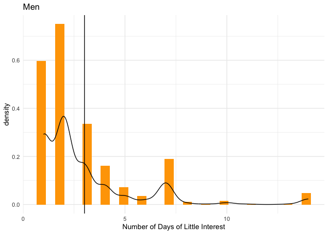

```r
#### Density plots for men to compare
mennamibia %>%
  ggplot(aes(x=SM813SN)) +
  geom_histogram(aes(y=..density..), fill = "orange") +
  geom_density(alpha = .2) +
  geom_vline(aes(xintercept=mean(SM813SN, na.rm = T)),
             color="black") +
  xlab("Number of Days of Little Interest") + ggtitle("Men") +
  theme_minimal()
```

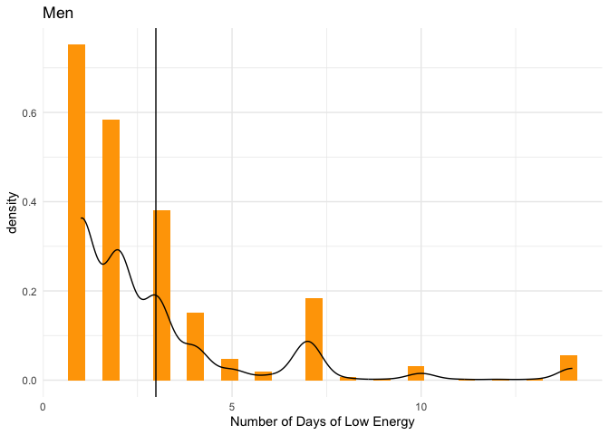

```r
mennamibia %>%
  ggplot(aes(x=SM813TN)) +
  geom_histogram(aes(y=..density..), fill = "orange") +
  geom_density(alpha = .2) +
  geom_vline(aes(xintercept=mean(SM813TN, na.rm = T)),
             color="black") +
  xlab("Number of Days of Low Energy") + ggtitle("Men") +
  theme_minimal()
```

#### Note: women, on average, report higher frequency of days of low energy and little interest than men. Those in urban areas report higher frequency of days of low energy and little interest, on average, than those in rural areas. When grouped by both strata (sex/gender) and place of residence, women in urban areas report the highest frequency days, followed by women in rural areas, men in rural areas, and men in urban areas. In other words, there are interesting interactions between gender and place of residence on a descriptive level.

```r
#### Merge data—create new mental health variables that account for reported frequencies

namibia_men_women <- namibia_men_women %>%
  mutate(nointerest_days = ifelse(little_interst == "No", 0, days_litte_interest),
         lowenergy_days = ifelse(lowenergy_sad == "No", 0, days_low_energy)
         )

namibia_men_women %>% head()
```

```
##   V000 V001 V002   V005 V012  V025 V021           V022         V106    V191
## 1  NM6    1    7 531957   44 Urban    1  Erongo, urban    Secondary  151934
## 2  NM6    2    2 564917   25 Rural    2 Caprivi, rural No education -120322
## 3  NM6    2    4 564917   31 Rural    2 Caprivi, rural      Primary -134413
## 4  NM6    2    5      0   61 Rural    2 Caprivi, rural No education -126248
## 5  NM6    2    5 564917   35 Rural    2 Caprivi, rural      Primary -126248
## 6  NM6    2    5 564917   16 Rural    2 Caprivi, rural    Secondary -126248
##   gender see_or_hear felt_worthless little_interst lowenergy_sad
## 1 female          No            Yes            Yes            No
## 2 female          No             No             No            No
## 3 female          No            Yes            Yes           Yes
## 4 female          No             No             No            No
## 5 female          No            Yes            Yes           Yes
## 6 female          No             No             No            No
##   days_litte_interest days_low_energy V744A V744B V744C V744D V744E abuse
## 1                   1              NA    No    No    No    No    No     0
## 2                  NA              NA   Yes   Yes   Yes   Yes   Yes     4
## 3                   7               4   Yes    No    No    No    No     1
## 4                  NA              NA    No   Yes   Yes   Yes   Yes     3
## 5                   7               3    No   Yes   Yes    No   Yes     2
## 6                  NA              NA    No    No    No    No    No     0
##   nointerest_days lowenergy_days
## 1               1              0
## 2               0              0
## 3               7              4
## 4               0              0
## 5               7              3
## 6               0              0
```

```r
#### Group by gender
namibia_men_women %>%
#  filter(felt_worthless != 3) %>%
  group_by(gender) %>%
  summarise(mean_lowenergy = mean(lowenergy_days, na.rm = T),
            mean_nointerest_days = mean(nointerest_days, na.rm = T),
            n_obs = length(lowenergy_days))
```

```
## # A tibble: 2 × 4
##   gender mean_lowenergy mean_nointerest_days n_obs
##   <chr>           <dbl>                <dbl> <int>
## 1 female          0.760                0.692 10018
## 2 male            0.375                0.375  4481
```

```r
#### Group by urban/rural
namibia_men_women %>%
  #  filter(felt_worthless != 3) %>%
  group_by(V025) %>%
  summarise(mean_lowenergy = mean(lowenergy_days, na.rm = T),
            mean_nointerest_days = mean(nointerest_days, na.rm = T),
            n_obs = length(lowenergy_days))
```

```
## # A tibble: 2 × 4
##   V025  mean_lowenergy mean_nointerest_days n_obs
##   <fct>          <dbl>                <dbl> <int>
## 1 Urban          0.706                0.635  7387
## 2 Rural          0.574                0.552  7112
```

```r
#### Group by both
namibia_men_women %>%
  group_by(gender, V025) %>%
  summarise(mean_lowenergy = mean(lowenergy_days, na.rm = T),
            mean_nointerest_days = mean(nointerest_days, na.rm = T),
            n_obs = length(lowenergy_days))
```

```
## # A tibble: 4 × 5
## # Groups:   gender [2]
##   gender V025  mean_lowenergy mean_nointerest_days n_obs
##   <chr>  <fct>          <dbl>                <dbl> <int>
## 1 female Urban          0.856                0.754  5163
## 2 female Rural          0.658                0.627  4855
## 3 male   Urban          0.357                0.359  2224
## 4 male   Rural          0.393                0.392  2257
```

```r
# Look at women's violence attitudes
namibia_women %>% count(V744A)
```

```
##        V744A    n
## 1         No 8375
## 2        Yes 1356
## 3 Don't know  283
## 4       <NA>    4
```

```r
namibia_men_women %>%
  group_by(gender) %>%
  count(V025)
```

```
## # A tibble: 4 × 3
## # Groups:   gender [2]
##   gender V025      n
##   <chr>  <fct> <int>
## 1 female Urban  5163
## 2 female Rural  4855
## 3 male   Urban  2224
## 4 male   Rural  2257
```

```r
namibia_men_women %>%
  group_by(gender) %>%
  count(little_interst)
```

```
## # A tibble: 8 × 3
## # Groups:   gender [2]
##   gender little_interst         n
##   <chr>  <fct>              <int>
## 1 female No                  7804
## 2 female Yes                 2157
## 3 female Dont know/not sure    52
## 4 female <NA>                   5
## 5 male   No                  3888
## 6 male   Yes                  553
## 7 male   Dont know/not sure    35
## 8 male   <NA>                   5
```

```r
namibia_men_women %>%
  group_by(gender) %>%
  count(lowenergy_sad)
```

```
## # A tibble: 8 × 3
## # Groups:   gender [2]
##   gender lowenergy_sad          n
##   <chr>  <fct>              <int>
## 1 female No                  7679
## 2 female Yes                 2299
## 3 female Dont know/not sure    36
## 4 female <NA>                   4
## 5 male   No                  3882
## 6 male   Yes                  558
## 7 male   Dont know/not sure    35
## 8 male   <NA>                   6
```

```r
namibia_men_women %>%
  group_by(gender) %>%
  count(felt_worthless)
```

```
## # A tibble: 6 × 3
## # Groups:   gender [2]
##   gender felt_worthless     n
##   <chr>  <fct>          <int>
## 1 female No              8659
## 2 female Yes             1347
## 3 female <NA>              12
## 4 male   No              4074
## 5 male   Yes              331
## 6 male   <NA>              76
```

```r
# merge namibia_men_women into hhwealth

namibia_hh_men_woman <- merge(namibia_men_women,hh_wealth, by.x =c("V000", "V001", "V002"), by.y = c("HV000", "HV001", "HV002"))

namibia_hh_men_woman %>%
  group_by(gender) %>%
  count(felt_worthless)
```

```
## # A tibble: 6 × 3
## # Groups:   gender [2]
##   gender felt_worthless     n
##   <chr>  <fct>          <int>
## 1 female No              8539
## 2 female Yes             1325
## 3 female <NA>              12
## 4 male   No              4002
## 5 male   Yes              325
## 6 male   <NA>              72
```

```r
#check results match
namibia_hh_men_woman %>%
  #  filter(felt_worthless != 3) %>%
  group_by(gender) %>%
  summarise(mean_lowenergy = mean(lowenergy_days, na.rm = T),
            mean_nointerest_days = mean(nointerest_days, na.rm = T),
            n_obs = length(lowenergy_days))
```

```
## # A tibble: 2 × 4
##   gender mean_lowenergy mean_nointerest_days n_obs
##   <chr>           <dbl>                <dbl> <int>
## 1 female          0.757                0.686  9876
## 2 male            0.372                0.374  4399
```

```r
namibia_hh_men_woman %>%
  #  filter(felt_worthless != 3) %>%
  group_by(V025) %>%
  summarise(mean_lowenergy = mean(lowenergy_days, na.rm = T),
            mean_nointerest_days = mean(nointerest_days, na.rm = T),
            n_obs = length(lowenergy_days))
```

```
## # A tibble: 2 × 4
##   V025  mean_lowenergy mean_nointerest_days n_obs
##   <fct>          <dbl>                <dbl> <int>
## 1 Urban          0.702                0.633  7271
## 2 Rural          0.573                0.546  7004
```

```r
namibia_hh_men_woman %>%
   filter(!is.na(lowenergy_days) & !is.na(nointerest_days)) %>%
  group_by(gender) %>%
  summarise(mean_lowenergy = mean(lowenergy_days),
            mean_nointerest_days = mean(nointerest_days),
            n_obs = length(lowenergy_days))
```

```
## # A tibble: 2 × 4
##   gender mean_lowenergy mean_nointerest_days n_obs
##   <chr>           <dbl>                <dbl> <int>
## 1 female          0.753                0.684  9791
## 2 male            0.373                0.375  4341
```

```r
#filter(!is.na(worthless))

namibia_hh_men_woman %>%
  filter(!is.na(lowenergy_days) & !is.na(nointerest_days)) %>%
  group_by(V025) %>%
  summarize(counts = sum(lowenergy_days), n = length(lowenergy_days))
```

```
## # A tibble: 2 × 3
##   V025  counts     n
##   <fct>  <dbl> <int>
## 1 Urban   5046  7182
## 2 Rural   3951  6950
```

```r
namibia_hh_men_woman %>%
  group_by(gender) %>%
  summarize(mean = mean(days_low_energy, na.rm = T),
            n = length(days_low_energy))
```

```
## # A tibble: 2 × 3
##   gender  mean     n
##   <chr>  <dbl> <int>
## 1 female  3.30  9876
## 2 male    3.00  4399
```

```r
namibia_hh_men_woman %>%
  #filter(lowenergy_days != 0) %>%
  group_by(gender, V025) %>%
  summarise(mean_lowenergy = mean(lowenergy_days, na.rm = T),
            mean_nointerest_days = mean(nointerest_days, na.rm = T),
            n_obs = length(lowenergy_days))
```

```
## # A tibble: 4 × 5
## # Groups:   gender [2]
##   gender V025  mean_lowenergy mean_nointerest_days n_obs
##   <chr>  <fct>          <dbl>                <dbl> <int>
## 1 female Urban          0.851                0.750  5091
## 2 female Rural          0.657                0.619  4785
## 3 male   Urban          0.352                0.360  2180
## 4 male   Rural          0.391                0.388  2219
```

```r
namibia_hh_men_woman %>%
  #  filter(felt_worthless != 3) %>%
  group_by(gender) %>%
  summarise(mean_lowenergy = mean(lowenergy_days, na.rm = T),
            mean_nointerest_days = mean(nointerest_days, na.rm = T),
            n_obs = length(lowenergy_days))
```

```
## # A tibble: 2 × 4
##   gender mean_lowenergy mean_nointerest_days n_obs
##   <chr>           <dbl>                <dbl> <int>
## 1 female          0.757                0.686  9876
## 2 male            0.372                0.374  4399
```

```r
# Three key variables felt_worthless, lowenergy_days, nointerest_days
```

|  | Urban (N=7271) | Rural (N=7004) | Overall (N=14275) |
| --- | --- | --- | --- |
| gender |  |  |  |
| female | 5091 (70.0%) | 4785 (68.3%) | 9876 (69.2%) |
| male | 2180 (30.0%) | 2219 (31.7%) | 4399 (30.8%) |
| V012 |  |  |  |
| Mean (SD) | 31.3 (11.5) | 31.8 (13.0) | 31.5 (12.2) |
| Median [Min, Max] | 29.0 [15.0, 64.0] | 29.0 [15.0, 64.0] | 29.0 [15.0, 64.0] |
| V106 |  |  |  |
| No education | 360 (5.0%) | 841 (12.0%) | 1201 (8.4%) |
| Primary | 1166 (16.0%) | 2256 (32.2%) | 3422 (24.0%) |
| Secondary | 4928 (67.8%) | 3656 (52.2%) | 8584 (60.1%) |
| Higher | 817 (11.2%) | 251 (3.6%) | 1068 (7.5%) |
| abuse |  |  |  |
| Mean (SD) | 0.418 (0.931) | 0.753 (1.20) | 0.583 (1.08) |
| Median [Min, Max] | 0 [0, 4.00] | 0 [0, 4.00] | 0 [0, 4.00] |
| Missing | 8 (0.1%) | 5 (0.1%) | 13 (0.1%) |
| Dim.1 |  |  |  |
| Mean (SD) | 0.183 (0.234) | -0.182 (0.204) | 0.00385 (0.286) |
| Median [Min, Max] | 0.235 [-0.422, 0.596] | -0.238 [-0.516, 0.575] | -0.0477 [-0.516, 0.596] |
| Dim.2 |  |  |  |
| Mean (SD) | -0.0406 (0.202) | 0.0827 (0.220) | 0.0199 (0.220) |
| Median [Min, Max] | -0.0796 [-0.332, 0.766] | 0.0711 [-0.333, 0.721] | -0.0388 [-0.333, 0.766] |
| felt_worthless |  |  |  |
| No | 6214 (85.5%) | 6327 (90.3%) | 12541 (87.9%) |
| Yes | 1015 (14.0%) | 635 (9.1%) | 1650 (11.6%) |
| Missing | 42 (0.6%) | 42 (0.6%) | 84 (0.6%) |
| nointerest_days |  |  |  |
| Mean (SD) | 0.633 (1.80) | 0.546 (1.57) | 0.590 (1.69) |
| Median [Min, Max] | 0 [0, 14.0] | 0 [0, 14.0] | 0 [0, 14.0] |
| Missing | 59 (0.8%) | 41 (0.6%) | 100 (0.7%) |
| lowenergy_days |  |  |  |
| Mean (SD) | 0.702 (1.95) | 0.573 (1.65) | 0.639 (1.81) |
| Median [Min, Max] | 0 [0, 14.0] | 0 [0, 14.0] | 0 [0, 14.0] |
| Missing | 54 (0.7%) | 31 (0.4%) | 85 (0.6%) |

|  | Urban (N=7387) | Rural (N=7112) | Overall (N=14499) |
| --- | --- | --- | --- |
| felt_worthless |  |  |  |
| No | 6310 (85.4%) | 6423 (90.3%) | 12733 (87.8%) |
| Yes | 1033 (14.0%) | 645 (9.1%) | 1678 (11.6%) |
| Missing | 44 (0.6%) | 44 (0.6%) | 88 (0.6%) |
| nointerest_days |  |  |  |
| Mean (SD) | 0.635 (1.80) | 0.552 (1.58) | 0.594 (1.70) |
| Median [Min, Max] | 0 [0, 14.0] | 0 [0, 14.0] | 0 [0, 14.0] |
| Missing | 61 (0.8%) | 41 (0.6%) | 102 (0.7%) |
| lowenergy_days |  |  |  |
| Mean (SD) | 0.706 (1.95) | 0.574 (1.65) | 0.641 (1.81) |
| Median [Min, Max] | 0 [0, 14.0] | 0 [0, 14.0] | 0 [0, 14.0] |
| Missing | 55 (0.7%) | 31 (0.4%) | 86 (0.6%) |
| little_interst |  |  |  |
| No | 5892 (79.8%) | 5800 (81.6%) | 11692 (80.6%) |
| Yes | 1438 (19.5%) | 1272 (17.9%) | 2710 (18.7%) |
| Dont know/not sure | 49 (0.7%) | 38 (0.5%) | 87 (0.6%) |
| Missing | 8 (0.1%) | 2 (0.0%) | 10 (0.1%) |
| lowenergy_sad |  |  |  |
| No | 5793 (78.4%) | 5768 (81.1%) | 11561 (79.7%) |
| Yes | 1542 (20.9%) | 1315 (18.5%) | 2857 (19.7%) |
| Dont know/not sure | 43 (0.6%) | 28 (0.4%) | 71 (0.5%) |
| Missing | 9 (0.1%) | 1 (0.0%) | 10 (0.1%) |

```
##
##  Pearson's Chi-squared test
##
## data:  namibia_hh_men_woman$felt_worthless and namibia_hh_men_woman$V025
## X-squared = 83.539, df = 1, p-value < 2.2e-16
```

```
##
##  Two Sample t-test
##
## data:  namibia_hh_men_woman$nointerest_days by namibia_hh_men_woman$V025
## t = 3.0561, df = 14173, p-value = 0.002246
## alternative hypothesis: true difference in means between group Urban and group Rural is not equal to 0
## 95 percent confidence interval:
##  0.03107699 0.14223617
## sample estimates:
## mean in group Urban mean in group Rural
##           0.6329728           0.5463162
```

```
##
##  Two Sample t-test
##
## data:  namibia_hh_men_woman$lowenergy_days by namibia_hh_men_woman$V025
## t = 4.2402, df = 14188, p-value = 2.248e-05
## alternative hypothesis: true difference in means between group Urban and group Rural is not equal to 0
## 95 percent confidence interval:
##  0.06923058 0.18826465
## sample estimates:
## mean in group Urban mean in group Rural
##           0.7018152           0.5730675
```

```
## # A tibble: 4 × 2
##   little_interst       mean
##   <fct>               <dbl>
## 1 No                   0
## 2 Yes                  3.15
## 3 Dont know/not sure NaN
## 4 <NA>               NaN
```

```
## # A tibble: 4 × 2
##   little_interst        sd
##   <fct>              <dbl>
## 1 No                  0
## 2 Yes                 2.67
## 3 Dont know/not sure NA
## 4 <NA>               NA
```

```
## # A tibble: 4 × 2
##   lowenergy_sad        mean
##   <fct>               <dbl>
## 1 No                   0
## 2 Yes                  3.24
## 3 Dont know/not sure NaN
## 4 <NA>               NaN
```

```
## # A tibble: 4 × 2
##   lowenergy_sad         sd
##   <fct>              <dbl>
## 1 No                  0
## 2 Yes                 2.86
## 3 Dont know/not sure NA
## 4 <NA>               NA
```

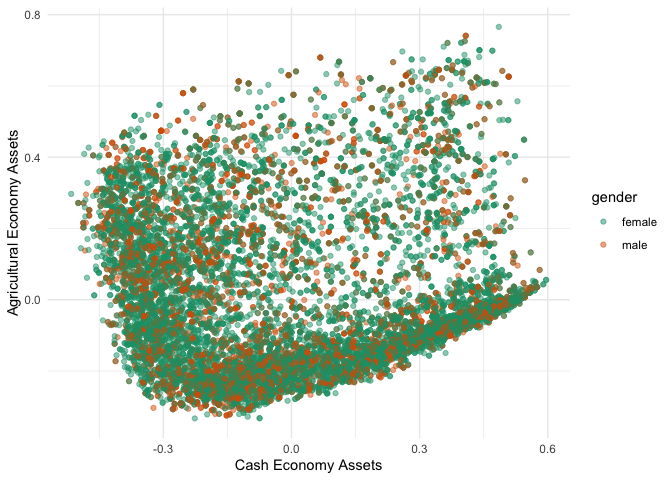

```r
ggplot(namibia_hh_men_woman, aes(x = Dim.1, y = Dim.2, col = gender)) +
  geom_point(alpha = 0.5) +
  scale_color_brewer(palette = "Dark2") +
  xlab("Cash Economy Assets") +
  ylab("Agricultural Economy Assets") +
  theme_minimal()
```

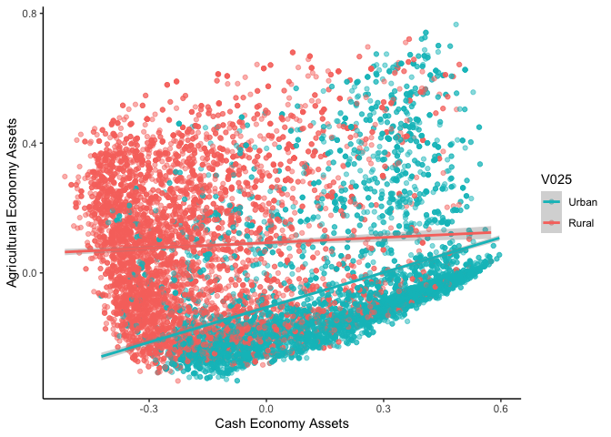

```r
ggplot(namibia_hh_men_woman, aes(x = Dim.1, y = Dim.2, col = V025)) +
  geom_point(alpha = 0.5) +
  xlab("Cash Economy Assets") +
  ylab("Agricultural Economy Assets") +
  scale_colour_manual(values = c("#00BFC4", "#F8766D")) +
  theme_classic() +
    geom_smooth(method=lm) #add linear trend line
```

```r
ggsave("Wealth Dims by Place.png")
```

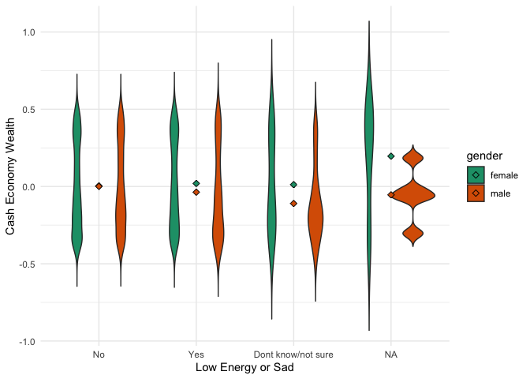

```r
p1 <-
  ggplot(namibia_hh_men_woman, aes(x = lowenergy_sad, y = Dim.1, fill = gender)) +
  geom_violin(trim = FALSE) +
  theme_minimal() +
    scale_fill_brewer(palette = "Dark2") +
  xlab("Low Energy or Sad") + ylab("Cash Economy Wealth")

p1 + stat_summary(fun.y=mean, geom="point", shape=23, size=2)
```

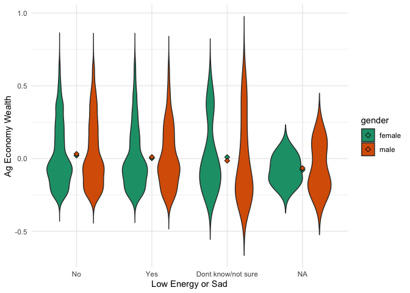

```r
p2 <-
  ggplot(namibia_hh_men_woman, aes(x = lowenergy_sad, y = Dim.2, fill = gender)) +
  geom_violin(trim = FALSE) +
  theme_minimal() +
    scale_fill_brewer(palette = "Dark2") +
  xlab("Low Energy or Sad") + ylab("Ag Economy Wealth")

p2 + stat_summary(fun.y=mean, geom="point", shape=23, size=2)
```

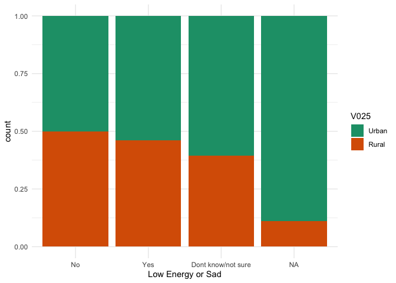

```r
ggplot(namibia_hh_men_woman, aes(x = lowenergy_sad, fill = V025)) +
    geom_bar(position = "fill") +
    scale_fill_brewer(palette = "Dark2") +
  xlab("Low Energy or Sad") +
  theme_minimal()
```

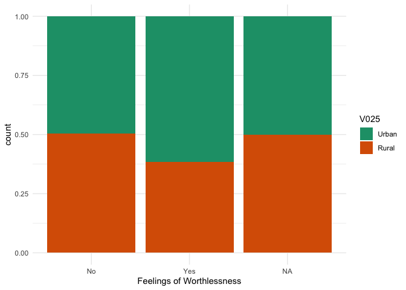

```r
ggplot(namibia_hh_men_woman, aes(x = felt_worthless, fill = V025)) +
    geom_bar(position = "fill") +
    scale_fill_brewer(palette = "Dark2") +
  xlab("Feelings of Worthlessness") +
  theme_minimal()
```

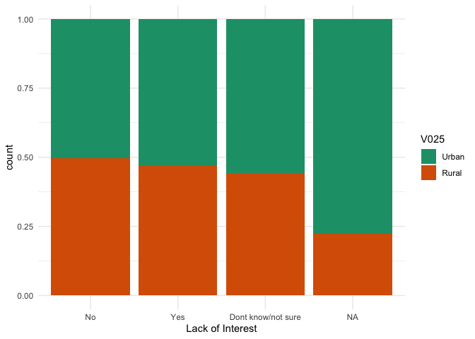

```r
ggplot(namibia_hh_men_woman, aes(x = little_interst, fill = V025)) +
    geom_bar(position = "fill") +
    scale_fill_brewer(palette = "Dark2") +
  xlab("Lack of Interest") +
  theme_minimal()
```

##### Analysis approaches to consider: Poisson regression can be used for count data (for instance, count of days of little interest or low energy, which we model here). However, if those data are overdispersed (conditional variance exceeds conditional mean), negative binomial regression may be more appropriate. Regardless of approach, wealth dimensions exhibit similar effects on days of little interest, with greater wealth in either dimensions associated with fewer days reported; however, the magnitude of effect is relatively greater of Dim2. As may be expected given this effect, rural residence is also associated with fewer days reported. Education is positively associated with days of no interest, with each successive education category associated with more days reported. The variable with the highest magnitude of effect in the model is sex. Sex-differentiation is also evident when considering low energy; however, the other effects are more mixed. In that model, Dim 1 and Dim2 differ in direction of effect, as they do with feeling worthless.

```r
#### Fit models
# install.packages("tidymodels")
# install.packages("poissonreg")

library(tidymodels)
library(poissonreg)

#### Model for feeling worthless

# Note: V012 = current age
log_spec <- logistic_reg() %>%
  set_engine("glm") %>%
  set_mode("classification") %>%
  fit(felt_worthless ~ gender + V012 + V025 + V106 +  gender + Dim.1 + Dim.2 + gender*abuse , data = namibia_hh_men_woman)

#log linear first
log_lin_spec<-poisson_reg()

log_spec
```

```
## parsnip model object
##
##
## Call:  stats::glm(formula = felt_worthless ~ gender + V012 + V025 +
##     V106 + gender + Dim.1 + Dim.2 + gender * abuse, family = stats::binomial,
##     data = data)
##
## Coefficients:
##      (Intercept)        gendermale              V012         V025Rural
##        -1.853436         -0.619282         -0.004035         -0.236726
##      V106Primary     V106Secondary        V106Higher             Dim.1
##         0.208827          0.199269          0.132526          0.484345
##            Dim.2             abuse  gendermale:abuse
##        -0.638174          0.037372          0.003603
##
## Degrees of Freedom: 14182 Total (i.e. Null);  14172 Residual
##   (92 observations deleted due to missingness)
## Null Deviance:       10200
## Residual Deviance: 9968  AIC: 9990
```

```r
class(log_spec)
```

```
## [1] "_glm"      "model_fit"
```

```r
tidy(log_spec)
```

```
## # A tibble: 11 × 5
##    term             estimate std.error statistic  p.value
##    <chr>               <dbl>     <dbl>     <dbl>    <dbl>
##  1 (Intercept)      -1.85      0.149    -12.4    1.61e-35
##  2 gendermale       -0.619     0.0728    -8.50   1.87e-17
##  3 V012             -0.00404   0.00234   -1.73   8.41e- 2
##  4 V025Rural        -0.237     0.0742    -3.19   1.43e- 3
##  5 V106Primary       0.209     0.121      1.73   8.37e- 2
##  6 V106Secondary     0.199     0.117      1.70   8.98e- 2
##  7 V106Higher        0.133     0.153      0.868  3.85e- 1
##  8 Dim.1             0.484     0.133      3.64   2.77e- 4
##  9 Dim.2            -0.638     0.138     -4.61   4.05e- 6
## 10 abuse             0.0374    0.0270     1.39   1.66e- 1
## 11 gendermale:abuse  0.00360   0.0676     0.0533 9.57e- 1
```

```r
library(sjPlot)
tab_model(log_spec)
```

|  | Dependent variable |  |  |
| --- | --- | --- | --- |
| Predictors | Odds Ratios | CI | p |
| (Intercept) | 0.16 | 0.12 – 0.21 | **<0.001** |
| gender [male] | 0.54 | 0.47 – 0.62 | **<0.001** |
| V012 | 1.00 | 0.99 – 1.00 | 0.084 |
| V025 [Rural] | 0.79 | 0.68 – 0.91 | **0.001** |
| V106 [Primary] | 1.23 | 0.97 – 1.56 | 0.084 |
| V106 [Secondary] | 1.22 | 0.97 – 1.54 | 0.090 |
| V106 [Higher] | 1.14 | 0.85 – 1.54 | 0.385 |
| Dim 1 | 1.62 | 1.25 – 2.11 | **<0.001** |
| Dim 2 | 0.53 | 0.40 – 0.69 | **<0.001** |
| abuse | 1.04 | 0.98 – 1.09 | 0.166 |
| gender [male] * abuse | 1.00 | 0.88 – 1.15 | 0.957 |
| Observations | 14183 |  |  |
| R<sup>2</sup> Tjur | 0.016 |  |  |

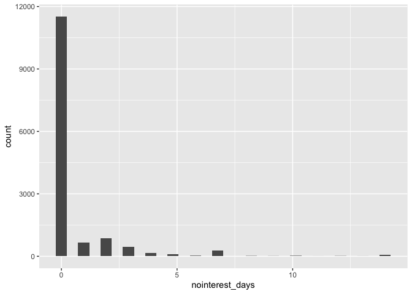

```r
namibia_hh_men_woman %>%
  ggplot(aes(x=nointerest_days)) + geom_histogram()
```

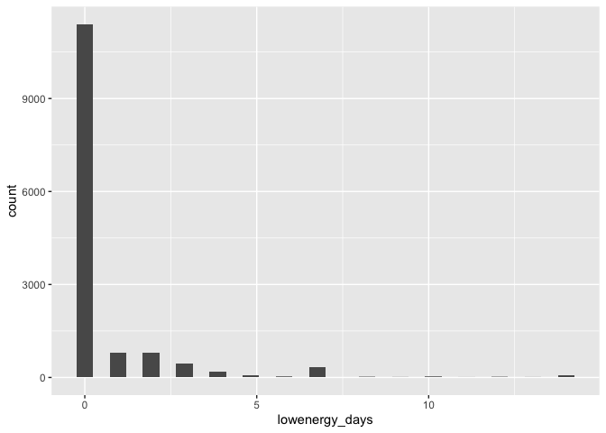

```r
namibia_hh_men_woman %>%
  ggplot(aes(x=lowenergy_days)) + geom_histogram()
```

```r
# Note: V012 = current age
#### Feelings of Worthlessness
log_spec_interact <- logistic_reg() %>%
  set_engine("glm") %>%
  set_mode("classification") %>%
  fit(felt_worthless ~ gender + V012 + V025 + V106 +  gender + Dim.1 + Dim.2 + gender*abuse + gender*Dim.1 + gender*Dim.2, data = namibia_hh_men_woman)

tidy(log_spec_interact)
```

```
## # A tibble: 13 × 5
##    term             estimate std.error statistic  p.value
##    <chr>               <dbl>     <dbl>     <dbl>    <dbl>
##  1 (Intercept)      -1.88      0.150     -12.6   3.23e-36
##  2 gendermale       -0.593     0.0741     -8.01  1.19e-15
##  3 V012             -0.00383   0.00234    -1.64  1.01e- 1
##  4 V025Rural        -0.234     0.0742     -3.16  1.60e- 3
##  5 V106Primary       0.218     0.121       1.80  7.14e- 2
##  6 V106Secondary     0.212     0.118       1.80  7.15e- 2
##  7 V106Higher        0.142     0.153       0.932 3.51e- 1
##  8 Dim.1             0.594     0.142       4.18  2.93e- 5
##  9 Dim.2            -0.569     0.154      -3.70  2.14e- 4
## 10 abuse             0.0460    0.0272      1.69  9.12e- 2
## 11 gendermale:abuse -0.0163    0.0683     -0.238 8.12e- 1
## 12 gendermale:Dim.1 -0.510     0.236      -2.16  3.05e- 2
## 13 gendermale:Dim.2 -0.323     0.312      -1.04  3.00e- 1
```

```r
tab_model(log_spec_interact)
```

|  | Dependent variable |  |  |
| --- | --- | --- | --- |
| Predictors | Odds Ratios | CI | p |
| (Intercept) | 0.15 | 0.11 – 0.20 | **<0.001** |
| gender [male] | 0.55 | 0.48 – 0.64 | **<0.001** |
| V012 | 1.00 | 0.99 – 1.00 | 0.101 |
| V025 [Rural] | 0.79 | 0.68 – 0.92 | **0.002** |
| V106 [Primary] | 1.24 | 0.98 – 1.57 | 0.071 |
| V106 [Secondary] | 1.24 | 0.98 – 1.56 | 0.071 |
| V106 [Higher] | 1.15 | 0.85 – 1.56 | 0.351 |
| Dim 1 | 1.81 | 1.37 – 2.39 | **<0.001** |
| Dim 2 | 0.57 | 0.42 – 0.76 | **<0.001** |
| abuse | 1.05 | 0.99 – 1.10 | 0.091 |
| gender [male] * abuse | 0.98 | 0.86 – 1.12 | 0.812 |
| gender [male] * Dim 1 | 0.60 | 0.38 – 0.95 | **0.030** |
| gender [male] * Dim 2 | 0.72 | 0.39 – 1.33 | 0.300 |
| Observations | 14183 |  |  |
| R<sup>2</sup> Tjur | 0.016 |  |  |

```r
#### Feelings of worthlessness with interactions
log_spec_interact2 <- logistic_reg() %>%
  set_engine("glm") %>%
  set_mode("classification") %>%
  fit(felt_worthless ~ gender + V012 + V025 + V106 +  gender + Dim.1 + Dim.2 + gender*abuse +  gender*V025, data = namibia_hh_men_woman)

tidy(log_spec_interact2)
```

```
## # A tibble: 12 × 5
##    term                  estimate std.error statistic  p.value
##    <chr>                    <dbl>     <dbl>     <dbl>    <dbl>
##  1 (Intercept)          -1.85       0.149    -12.4    1.89e-35
##  2 gendermale           -0.655      0.0891    -7.35   2.00e-13
##  3 V012                 -0.00398    0.00234   -1.70   8.88e- 2
##  4 V025Rural            -0.257      0.0797    -3.22   1.27e- 3
##  5 V106Primary           0.211      0.121      1.75   8.09e- 2
##  6 V106Secondary         0.203      0.118      1.73   8.40e- 2
##  7 V106Higher            0.136      0.153      0.891  3.73e- 1
##  8 Dim.1                 0.483      0.133      3.62   2.93e- 4
##  9 Dim.2                -0.639      0.138     -4.62   3.87e- 6
## 10 abuse                 0.0391     0.0271     1.44   1.49e- 1
## 11 gendermale:abuse     -0.000989   0.0680    -0.0146 9.88e- 1
## 12 gendermale:V025Rural  0.0931     0.133      0.699  4.85e- 1
```

```r
tab_model(log_spec, log_spec_interact, log_spec_interact2, dv.labels = c("Worthlessness1", "Worthlessness2", "Worthlessness3"))
```

|  | Worthlessness1 |  |  | Worthlessness2 |  |  | Worthlessness3 |  |  |
| --- | --- | --- | --- | --- | --- | --- | --- | --- | --- |
| Predictors | Odds Ratios | CI | p | Odds Ratios | CI | p | Odds Ratios | CI | p |
| (Intercept) | 0.16 | 0.12 – 0.21 | **<0.001** | 0.15 | 0.11 – 0.20 | **<0.001** | 0.16 | 0.12 – 0.21 | **<0.001** |
| gender [male] | 0.54 | 0.47 – 0.62 | **<0.001** | 0.55 | 0.48 – 0.64 | **<0.001** | 0.52 | 0.44 – 0.62 | **<0.001** |
| V012 | 1.00 | 0.99 – 1.00 | 0.084 | 1.00 | 0.99 – 1.00 | 0.101 | 1.00 | 0.99 – 1.00 | 0.089 |
| V025 [Rural] | 0.79 | 0.68 – 0.91 | **0.001** | 0.79 | 0.68 – 0.92 | **0.002** | 0.77 | 0.66 – 0.90 | **0.001** |
| V106 [Primary] | 1.23 | 0.97 – 1.56 | 0.084 | 1.24 | 0.98 – 1.57 | 0.071 | 1.23 | 0.97 – 1.56 | 0.081 |
| V106 [Secondary] | 1.22 | 0.97 – 1.54 | 0.090 | 1.24 | 0.98 – 1.56 | 0.071 | 1.23 | 0.97 – 1.54 | 0.084 |
| V106 [Higher] | 1.14 | 0.85 – 1.54 | 0.385 | 1.15 | 0.85 – 1.56 | 0.351 | 1.15 | 0.85 – 1.55 | 0.373 |
| Dim 1 | 1.62 | 1.25 – 2.11 | **<0.001** | 1.81 | 1.37 – 2.39 | **<0.001** | 1.62 | 1.25 – 2.10 | **<0.001** |
| Dim 2 | 0.53 | 0.40 – 0.69 | **<0.001** | 0.57 | 0.42 – 0.76 | **<0.001** | 0.53 | 0.40 – 0.69 | **<0.001** |
| abuse | 1.04 | 0.98 – 1.09 | 0.166 | 1.05 | 0.99 – 1.10 | 0.091 | 1.04 | 0.99 – 1.10 | 0.149 |
| gender [male] * abuse | 1.00 | 0.88 – 1.15 | 0.957 | 0.98 | 0.86 – 1.12 | 0.812 | 1.00 | 0.87 – 1.14 | 0.988 |
| gender [male] * Dim 1 |  |  |  | 0.60 | 0.38 – 0.95 | **0.030** |  |  |  |
| gender [male] * Dim 2 |  |  |  | 0.72 | 0.39 – 1.33 | 0.300 |  |  |  |
| gender [male] * V025 [Rural] |  |  |  |  |  |  | 1.10 | 0.85 – 1.42 | 0.485 |
| Observations | 14183 |  |  | 14183 |  |  | 14183 |  |  |
| R<sup>2</sup> Tjur | 0.016 |  |  | 0.016 |  |  | 0.016 |  |  |

```r
#### No interest - poisson
log_lin_fit_nointerest <-
  log_lin_spec %>%
  fit(nointerest_days ~ gender + V012 + V025 + V106 +  gender + Dim.1 + Dim.2 + gender*abuse, data = namibia_hh_men_woman)
log_lin_fit_nointerest
```

```
## parsnip model object
##
##
## Call:  stats::glm(formula = nointerest_days ~ gender + V012 + V025 +
##     V106 + gender + Dim.1 + Dim.2 + gender * abuse, family = stats::poisson,
##     data = data)
##
## Coefficients:
##      (Intercept)        gendermale              V012         V025Rural
##        -0.517341         -0.654115         -0.003258         -0.162347
##      V106Primary     V106Secondary        V106Higher             Dim.1
##         0.281367          0.285898          0.386818         -0.119771
##            Dim.2             abuse  gendermale:abuse
##        -0.208838          0.067361          0.139961
##
## Degrees of Freedom: 14166 Total (i.e. Null);  14156 Residual
##   (108 observations deleted due to missingness)
## Null Deviance:       32680
## Residual Deviance: 31890     AIC: 39350
```

```r
log_lin_fit_nointerest %>% tidy()
```

```
## # A tibble: 11 × 5
##    term             estimate std.error statistic  p.value
##    <chr>               <dbl>     <dbl>     <dbl>    <dbl>
##  1 (Intercept)      -0.517    0.0622       -8.32 8.59e-17
##  2 gendermale       -0.654    0.0320      -20.4  1.01e-92
##  3 V012             -0.00326  0.000966     -3.37 7.48e- 4
##  4 V025Rural        -0.162    0.0308       -5.27 1.40e- 7
##  5 V106Primary       0.281    0.0500        5.62 1.88e- 8
##  6 V106Secondary     0.286    0.0490        5.83 5.42e- 9
##  7 V106Higher        0.387    0.0639        6.06 1.38e- 9
##  8 Dim.1            -0.120    0.0558       -2.15 3.19e- 2
##  9 Dim.2            -0.209    0.0556       -3.75 1.74e- 4
## 10 abuse             0.0674   0.0105        6.43 1.26e-10
## 11 gendermale:abuse  0.140    0.0248        5.65 1.59e- 8
```

```r
tidy(log_lin_fit_nointerest, conf.int = T, conf.level = .9)
```

```
## # A tibble: 11 × 7
##    term             estimate std.error statistic  p.value conf.low conf.high
##    <chr>               <dbl>     <dbl>     <dbl>    <dbl>    <dbl>     <dbl>
##  1 (Intercept)      -0.517    0.0622       -8.32 8.59e-17 -0.620    -0.416
##  2 gendermale       -0.654    0.0320      -20.4  1.01e-92 -0.707    -0.602
##  3 V012             -0.00326  0.000966     -3.37 7.48e- 4 -0.00485  -0.00167
##  4 V025Rural        -0.162    0.0308       -5.27 1.40e- 7 -0.213    -0.112
##  5 V106Primary       0.281    0.0500        5.62 1.88e- 8  0.200     0.364
##  6 V106Secondary     0.286    0.0490        5.83 5.42e- 9  0.206     0.367
##  7 V106Higher        0.387    0.0639        6.06 1.38e- 9  0.282     0.492
##  8 Dim.1            -0.120    0.0558       -2.15 3.19e- 2 -0.212    -0.0280
##  9 Dim.2            -0.209    0.0556       -3.75 1.74e- 4 -0.301    -0.118
## 10 abuse             0.0674   0.0105        6.43 1.26e-10  0.0501    0.0845
## 11 gendermale:abuse  0.140    0.0248        5.65 1.59e- 8  0.0989    0.180
```

```r
#### No interest with interactions
log_lin_fit_nointerest_interact <-
  log_lin_spec %>%
  fit(nointerest_days ~ gender + V012 + V025 + V106 +  gender + Dim.1 + Dim.2 + gender*abuse + gender*Dim.1 + gender*Dim.2, data = namibia_hh_men_woman)

tidy(log_lin_fit_nointerest_interact, conf.int = T, conf.level = .9)
```

```
## # A tibble: 13 × 7
##    term             estimate std.error statistic  p.value conf.low conf.high
##    <chr>               <dbl>     <dbl>     <dbl>    <dbl>    <dbl>     <dbl>
##  1 (Intercept)      -0.552    0.0625      -8.84  9.75e-19 -0.655    -0.450
##  2 gendermale       -0.645    0.0323     -20.0   1.14e-88 -0.698    -0.592
##  3 V012             -0.00295  0.000968    -3.04  2.33e- 3 -0.00454  -0.00136
##  4 V025Rural        -0.161    0.0308      -5.21  1.90e- 7 -0.211    -0.110
##  5 V106Primary       0.292    0.0501       5.83  5.43e- 9  0.210     0.375
##  6 V106Secondary     0.302    0.0491       6.15  7.65e-10  0.222     0.383
##  7 V106Higher        0.398    0.0639       6.22  4.83e-10  0.293     0.503
##  8 Dim.1             0.0238   0.0590       0.403 6.87e- 1 -0.0733    0.121
##  9 Dim.2            -0.142    0.0613      -2.32  2.03e- 2 -0.244    -0.0418
## 10 abuse             0.0782   0.0106       7.40  1.38e-13  0.0608    0.0955
## 11 gendermale:abuse  0.114    0.0251       4.52  6.15e- 6  0.0719    0.155
## 12 gendermale:Dim.1 -0.748    0.103       -7.28  3.30e-13 -0.917    -0.579
## 13 gendermale:Dim.2 -0.342    0.128       -2.68  7.31e- 3 -0.553    -0.133
```

```r
log_lin_fit_nointerest_interact2 <-
  log_lin_spec %>%
  fit(nointerest_days ~ gender + V012 + V025 + V106 +  gender + Dim.1 + Dim.2 + gender*abuse + gender*V025, data = namibia_hh_men_woman)

tidy(log_lin_fit_nointerest_interact2, conf.int = T, conf.level = .9)
```

```
## # A tibble: 12 × 7
##    term                 estimate std.error statistic  p.value conf.low conf.high
##    <chr>                   <dbl>     <dbl>     <dbl>    <dbl>    <dbl>     <dbl>
##  1 (Intercept)          -0.512    0.0621       -8.24 1.77e-16 -0.615    -0.410
##  2 gendermale           -0.778    0.0416      -18.7  4.71e-78 -0.846    -0.710
##  3 V012                 -0.00306  0.000967     -3.17 1.55e- 3 -0.00465  -0.00147
##  4 V025Rural            -0.217    0.0329       -6.61 3.74e-11 -0.272    -0.163
##  5 V106Primary           0.287    0.0501        5.74 9.52e- 9  0.206     0.370
##  6 V106Secondary         0.298    0.0491        6.06 1.33e- 9  0.218     0.379
##  7 V106Higher            0.397    0.0639        6.22 5.06e-10  0.292     0.503
##  8 Dim.1                -0.124    0.0559       -2.23 2.59e- 2 -0.216    -0.0326
##  9 Dim.2                -0.213    0.0556       -3.82 1.32e- 4 -0.304    -0.121
## 10 abuse                 0.0720   0.0105        6.85 7.48e-12  0.0546    0.0892
## 11 gendermale:abuse      0.127    0.0250        5.10 3.47e- 7  0.0858    0.168
## 12 gendermale:V025Rural  0.273    0.0558        4.89 1.01e- 6  0.181     0.365
```

```r
tab_model(log_lin_fit_nointerest, log_lin_fit_nointerest_interact, log_lin_fit_nointerest_interact2, dv.labels = c("Low Interest1", "LowInterest2", "LowInterest3"))
```

|  | Low Interest1 |  |  | LowInterest2 |  |  | LowInterest3 |  |  |
| --- | --- | --- | --- | --- | --- | --- | --- | --- | --- |
| Predictors | Incidence Rate Ratios | CI | p | Incidence Rate Ratios | CI | p | Incidence Rate Ratios | CI | p |
| (Intercept) | 0.60 | 0.53 – 0.67 | **<0.001** | 0.58 | 0.51 – 0.65 | **<0.001** | 0.60 | 0.53 – 0.68 | **<0.001** |
| gender [male] | 0.52 | 0.49 – 0.55 | **<0.001** | 0.52 | 0.49 – 0.56 | **<0.001** | 0.46 | 0.42 – 0.50 | **<0.001** |
| V012 | 1.00 | 0.99 – 1.00 | **0.001** | 1.00 | 1.00 – 1.00 | **0.002** | 1.00 | 1.00 – 1.00 | **0.002** |
| V025 [Rural] | 0.85 | 0.80 – 0.90 | **<0.001** | 0.85 | 0.80 – 0.90 | **<0.001** | 0.80 | 0.75 – 0.86 | **<0.001** |
| V106 [Primary] | 1.32 | 1.20 – 1.46 | **<0.001** | 1.34 | 1.21 – 1.48 | **<0.001** | 1.33 | 1.21 – 1.47 | **<0.001** |
| V106 [Secondary] | 1.33 | 1.21 – 1.47 | **<0.001** | 1.35 | 1.23 – 1.49 | **<0.001** | 1.35 | 1.22 – 1.48 | **<0.001** |
| V106 [Higher] | 1.47 | 1.30 – 1.67 | **<0.001** | 1.49 | 1.31 – 1.69 | **<0.001** | 1.49 | 1.31 – 1.69 | **<0.001** |
| Dim 1 | 0.89 | 0.80 – 0.99 | **0.032** | 1.02 | 0.91 – 1.15 | 0.687 | 0.88 | 0.79 – 0.99 | **0.026** |
| Dim 2 | 0.81 | 0.73 – 0.90 | **<0.001** | 0.87 | 0.77 – 0.98 | **0.020** | 0.81 | 0.72 – 0.90 | **<0.001** |
| abuse | 1.07 | 1.05 – 1.09 | **<0.001** | 1.08 | 1.06 – 1.10 | **<0.001** | 1.07 | 1.05 – 1.10 | **<0.001** |
| gender [male] * abuse | 1.15 | 1.10 – 1.21 | **<0.001** | 1.12 | 1.07 – 1.18 | **<0.001** | 1.14 | 1.08 – 1.19 | **<0.001** |
| gender [male] * Dim 1 |  |  |  | 0.47 | 0.39 – 0.58 | **<0.001** |  |  |  |
| gender [male] * Dim 2 |  |  |  | 0.71 | 0.55 – 0.91 | **0.007** |  |  |  |
| gender [male] * V025 [Rural] |  |  |  |  |  |  | 1.31 | 1.18 – 1.47 | **<0.001** |
| Observations | 14167 |  |  | 14167 |  |  | 14167 |  |  |
| R<sup>2</sup> Nagelkerke | 0.060 |  |  | 0.065 |  |  | 0.062 |  |  |

```r
##### Low energy- poisson
log_lin_fit_lowenergy <-
  log_lin_spec %>%
  fit(lowenergy_days ~ gender + V012 + V025 + V106 +  gender + Dim.1 + Dim.2  + gender*abuse, data = namibia_hh_men_woman)
log_lin_fit_lowenergy
```

```
## parsnip model object
##
##
## Call:  stats::glm(formula = lowenergy_days ~ gender + V012 + V025 +
##     V106 + gender + Dim.1 + Dim.2 + gender * abuse, family = stats::poisson,
##     data = data)
##
## Coefficients:
##      (Intercept)        gendermale              V012         V025Rural
##       -0.5081989        -0.6828372         0.0013111        -0.1647963
##      V106Primary     V106Secondary        V106Higher             Dim.1
##        0.2864148         0.2118292         0.1756976         0.0595455
##            Dim.2             abuse  gendermale:abuse
##       -0.3234019         0.0758703         0.0006532
##
## Degrees of Freedom: 14181 Total (i.e. Null);  14171 Residual
##   (93 observations deleted due to missingness)
## Null Deviance:       34920
## Residual Deviance: 33910     AIC: 41770
```

```r
log_lin_fit_lowenergy %>% tidy()
```

```
## # A tibble: 11 × 5
##    term              estimate std.error statistic   p.value
##    <chr>                <dbl>     <dbl>     <dbl>     <dbl>
##  1 (Intercept)      -0.508     0.0590     -8.61   7.00e- 18
##  2 gendermale       -0.683     0.0310    -22.0    3.00e-107
##  3 V012              0.00131   0.000913    1.44   1.51e-  1
##  4 V025Rural        -0.165     0.0295     -5.58   2.44e-  8
##  5 V106Primary       0.286     0.0469      6.11   9.93e- 10
##  6 V106Secondary     0.212     0.0462      4.58   4.60e-  6
##  7 V106Higher        0.176     0.0617      2.85   4.43e-  3
##  8 Dim.1             0.0595    0.0535      1.11   2.66e-  1
##  9 Dim.2            -0.323     0.0542     -5.97   2.35e-  9
## 10 abuse             0.0759    0.00990     7.66   1.83e- 14
## 11 gendermale:abuse  0.000653  0.0274      0.0238 9.81e-  1
```

```r
tidy(log_lin_fit_lowenergy, conf.int = T, conf.level = .9)
```

```
## # A tibble: 11 × 7
##    term              estimate std.error statistic   p.value  conf.low conf.high
##    <chr>                <dbl>     <dbl>     <dbl>     <dbl>     <dbl>     <dbl>
##  1 (Intercept)      -0.508     0.0590     -8.61   7.00e- 18 -0.606     -0.412
##  2 gendermale       -0.683     0.0310    -22.0    3.00e-107 -0.734     -0.632
##  3 V012              0.00131   0.000913    1.44   1.51e-  1 -0.000193   0.00281
##  4 V025Rural        -0.165     0.0295     -5.58   2.44e-  8 -0.213     -0.116
##  5 V106Primary       0.286     0.0469      6.11   9.93e- 10  0.210      0.364
##  6 V106Secondary     0.212     0.0462      4.58   4.60e-  6  0.136      0.289
##  7 V106Higher        0.176     0.0617      2.85   4.43e-  3  0.0742     0.277
##  8 Dim.1             0.0595    0.0535      1.11   2.66e-  1 -0.0285     0.148
##  9 Dim.2            -0.323     0.0542     -5.97   2.35e-  9 -0.413     -0.235
## 10 abuse             0.0759    0.00990     7.66   1.83e- 14  0.0595     0.0921
## 11 gendermale:abuse  0.000653  0.0274      0.0238 9.81e-  1 -0.0450     0.0453
```

```r
#### Low energy interaction effects
log_lin_fit_lowenergy_interact <-
  log_lin_spec %>%
  fit(lowenergy_days ~ gender + V012 + V025 + V106 +  gender + Dim.1 + Dim.2  + gender*abuse + gender*Dim.1 + gender*Dim.2, data = namibia_hh_men_woman)
log_lin_fit_lowenergy_interact
```

```
## parsnip model object
##
##
## Call:  stats::glm(formula = lowenergy_days ~ gender + V012 + V025 +
##     V106 + gender + Dim.1 + Dim.2 + gender * abuse + gender *
##     Dim.1 + gender * Dim.2, family = stats::poisson, data = data)
##
## Coefficients:
##      (Intercept)        gendermale              V012         V025Rural
##        -0.541194         -0.669776          0.001639         -0.163788
##      V106Primary     V106Secondary        V106Higher             Dim.1
##         0.295348          0.226678          0.188669          0.184081
##            Dim.2             abuse  gendermale:abuse  gendermale:Dim.1
##        -0.329222          0.085079         -0.024569         -0.703997
## gendermale:Dim.2
##         0.010987
##
## Degrees of Freedom: 14181 Total (i.e. Null);  14169 Residual
##   (93 observations deleted due to missingness)
## Null Deviance:       34920
## Residual Deviance: 33860     AIC: 41730
```

```r
log_lin_fit_lowenergy_interact2 <-
  log_lin_spec %>%
  fit(lowenergy_days ~ gender + V012 + V025 + V106 +  gender + Dim.1 + Dim.2  + gender*abuse + gender*V025, data = namibia_hh_men_woman)
log_lin_fit_lowenergy_interact2
```

```
## parsnip model object
##
##
## Call:  stats::glm(formula = lowenergy_days ~ gender + V012 + V025 +
##     V106 + gender + Dim.1 + Dim.2 + gender * abuse + gender *
##     V025, family = stats::poisson, data = data)
##
## Coefficients:
##          (Intercept)            gendermale                  V012
##            -0.501538             -0.867560              0.001564
##            V025Rural           V106Primary         V106Secondary
##            -0.241095              0.295339              0.228438
##           V106Higher                 Dim.1                 Dim.2
##             0.191248              0.052161             -0.328368
##                abuse      gendermale:abuse  gendermale:V025Rural
##             0.082185             -0.018141              0.408300
##
## Degrees of Freedom: 14181 Total (i.e. Null);  14170 Residual
##   (93 observations deleted due to missingness)
## Null Deviance:       34920
## Residual Deviance: 33860     AIC: 41720
```

```r
tab_model(log_lin_fit_lowenergy, log_lin_fit_lowenergy_interact, log_lin_fit_lowenergy_interact2, dv.labels = c("Low Energy1", "LowEnergy2", "LowEnergy3"))
```

|  | Low Energy1 |  |  | LowEnergy2 |  |  | LowEnergy3 |  |  |
| --- | --- | --- | --- | --- | --- | --- | --- | --- | --- |
| Predictors | Incidence Rate Ratios | CI | p | Incidence Rate Ratios | CI | p | Incidence Rate Ratios | CI | p |
| (Intercept) | 0.60 | 0.54 – 0.68 | **<0.001** | 0.58 | 0.52 – 0.65 | **<0.001** | 0.61 | 0.54 – 0.68 | **<0.001** |
| gender [male] | 0.51 | 0.48 – 0.54 | **<0.001** | 0.51 | 0.48 – 0.54 | **<0.001** | 0.42 | 0.39 – 0.46 | **<0.001** |
| V012 | 1.00 | 1.00 – 1.00 | 0.151 | 1.00 | 1.00 – 1.00 | 0.073 | 1.00 | 1.00 – 1.00 | 0.087 |
| V025 [Rural] | 0.85 | 0.80 – 0.90 | **<0.001** | 0.85 | 0.80 – 0.90 | **<0.001** | 0.79 | 0.74 – 0.84 | **<0.001** |
| V106 [Primary] | 1.33 | 1.21 – 1.46 | **<0.001** | 1.34 | 1.23 – 1.47 | **<0.001** | 1.34 | 1.23 – 1.47 | **<0.001** |
| V106 [Secondary] | 1.24 | 1.13 – 1.35 | **<0.001** | 1.25 | 1.15 – 1.37 | **<0.001** | 1.26 | 1.15 – 1.38 | **<0.001** |
| V106 [Higher] | 1.19 | 1.06 – 1.35 | **0.004** | 1.21 | 1.07 – 1.36 | **0.002** | 1.21 | 1.07 – 1.37 | **0.002** |
| Dim 1 | 1.06 | 0.96 – 1.18 | 0.266 | 1.20 | 1.08 – 1.34 | **0.001** | 1.05 | 0.95 – 1.17 | 0.330 |
| Dim 2 | 0.72 | 0.65 – 0.80 | **<0.001** | 0.72 | 0.64 – 0.81 | **<0.001** | 0.72 | 0.65 – 0.80 | **<0.001** |
| abuse | 1.08 | 1.06 – 1.10 | **<0.001** | 1.09 | 1.07 – 1.11 | **<0.001** | 1.09 | 1.06 – 1.11 | **<0.001** |
| gender [male] * abuse | 1.00 | 0.95 – 1.06 | 0.981 | 0.98 | 0.92 – 1.03 | 0.377 | 0.98 | 0.93 – 1.04 | 0.512 |
| gender [male] * Dim 1 |  |  |  | 0.49 | 0.41 – 0.60 | **<0.001** |  |  |  |
| gender [male] * Dim 2 |  |  |  | 1.01 | 0.79 – 1.29 | 0.930 |  |  |  |
| gender [male] * V025 [Rural] |  |  |  |  |  |  | 1.50 | 1.35 – 1.68 | **<0.001** |
| Observations | 14182 |  |  | 14182 |  |  | 14182 |  |  |
| R<sup>2</sup> Nagelkerke | 0.075 |  |  | 0.079 |  |  | 0.079 |  |  |

```r
# Negative binomial
library(MASS)
summary(m1 <- glm.nb(nointerest_days ~ gender + V012 + V025 + V106 +  gender*abuse + Dim.1 + Dim.2 , data = namibia_hh_men_woman))
```

```
##
## Call:
## glm.nb(formula = nointerest_days ~ gender + V012 + V025 + V106 +
##     gender * abuse + Dim.1 + Dim.2, data = namibia_hh_men_woman,
##     init.theta = 0.122992938, link = log)
##
## Deviance Residuals:
##     Min       1Q   Median       3Q      Max
## -0.7552  -0.6836  -0.6491  -0.5520   2.8462
##
## Coefficients:
##                   Estimate Std. Error z value Pr(>|z|)
## (Intercept)      -0.507283   0.142024  -3.572 0.000355 ***
## gendermale       -0.684368   0.066959 -10.221  < 2e-16 ***
## V012             -0.004910   0.002294  -2.140 0.032344 *
## V025Rural        -0.154771   0.074449  -2.079 0.037627 *
## V106Primary       0.319616   0.110515   2.892 0.003827 **
## V106Secondary     0.338578   0.107817   3.140 0.001688 **
## V106Higher        0.419234   0.147966   2.833 0.004607 **
## abuse             0.067055   0.027976   2.397 0.016534 *
## Dim.1            -0.181103   0.134992  -1.342 0.179732
## Dim.2            -0.276512   0.131529  -2.102 0.035527 *
## gendermale:abuse  0.163238   0.059738   2.733 0.006285 **
## ---
## Signif. codes:  0 '***' 0.001 '**' 0.01 '*' 0.05 '.' 0.1 ' ' 1
##
## (Dispersion parameter for Negative Binomial(0.123) family taken to be 1)
##
##     Null deviance: 6676.5  on 14166  degrees of freedom
## Residual deviance: 6520.3  on 14156  degrees of freedom
##   (108 observations deleted due to missingness)
## AIC: 24219
##
## Number of Fisher Scoring iterations: 1
##
##
##               Theta:  0.12299
##           Std. Err.:  0.00346
##
##  2 x log-likelihood:  -24194.74300
```

```r
summary(m2 <- glm.nb(lowenergy_days ~ gender + V012 + V025 + V106 +  gender*abuse + Dim.1 + Dim.2 , data = namibia_hh_men_woman))
```

```
##
## Call:
## glm.nb(formula = lowenergy_days ~ gender + V012 + V025 + V106 +
##     gender * abuse + Dim.1 + Dim.2, data = namibia_hh_men_woman,
##     init.theta = 0.1277318483, link = log)
##
## Deviance Residuals:
##     Min       1Q   Median       3Q      Max
## -0.7745  -0.7062  -0.6629  -0.5662   3.3842
##
## Coefficients:
##                   Estimate Std. Error z value Pr(>|z|)
## (Intercept)      -0.527989   0.138389  -3.815 0.000136 ***
## gendermale       -0.676975   0.065286 -10.369  < 2e-16 ***
## V012              0.001143   0.002232   0.512 0.608617
## V025Rural        -0.139335   0.072703  -1.916 0.055302 .
## V106Primary       0.282998   0.107260   2.638 0.008329 **
## V106Secondary     0.221871   0.104795   2.117 0.034244 *
## V106Higher        0.260626   0.144124   1.808 0.070552 .
## abuse             0.075195   0.027261   2.758 0.005810 **
## Dim.1             0.029114   0.131839   0.221 0.825222
## Dim.2            -0.330979   0.128643  -2.573 0.010087 *
## gendermale:abuse  0.011186   0.059867   0.187 0.851784
## ---
## Signif. codes:  0 '***' 0.001 '**' 0.01 '*' 0.05 '.' 0.1 ' ' 1
##
## (Dispersion parameter for Negative Binomial(0.1277) family taken to be 1)
##
##     Null deviance: 6959.3  on 14181  degrees of freedom
## Residual deviance: 6782.1  on 14171  degrees of freedom
##   (93 observations deleted due to missingness)
## AIC: 25269
##
## Number of Fisher Scoring iterations: 1
##
##
##               Theta:  0.12773
##           Std. Err.:  0.00349
##
##  2 x log-likelihood:  -25244.86600
```

```r
summary(m3 <- glm.nb(lowenergy_days ~  V012 + V025 + V106 + abuse + Dim.1 + Dim.2 , data = namibia_hh_men_woman, subset = gender == "female"))
```

```
##
## Call:
## glm.nb(formula = lowenergy_days ~ V012 + V025 + V106 + abuse +
##     Dim.1 + Dim.2, data = namibia_hh_men_woman, subset = gender ==
##     "female", init.theta = 0.1476676387, link = log)
##
## Deviance Residuals:
##     Min       1Q   Median       3Q      Max
## -0.8310  -0.7484  -0.7112  -0.6641   2.3974
##
## Coefficients:
##                Estimate Std. Error z value Pr(>|z|)
## (Intercept)   -0.540544   0.157721  -3.427 0.000610 ***
## V012           0.003832   0.002527   1.517 0.129337
## V025Rural     -0.227078   0.081197  -2.797 0.005164 **
## V106Primary    0.258803   0.125129   2.068 0.038613 *
## V106Secondary  0.194546   0.122116   1.593 0.111132
## V106Higher    -0.049408   0.165998  -0.298 0.765976
## abuse          0.089224   0.026015   3.430 0.000604 ***
## Dim.1          0.206965   0.146851   1.409 0.158732
## Dim.2         -0.279367   0.144710  -1.931 0.053542 .
## ---
## Signif. codes:  0 '***' 0.001 '**' 0.01 '*' 0.05 '.' 0.1 ' ' 1
##
## (Dispersion parameter for Negative Binomial(0.1477) family taken to be 1)
##
##     Null deviance: 5348.7  on 9826  degrees of freedom
## Residual deviance: 5301.1  on 9818  degrees of freedom
##   (49 observations deleted due to missingness)
## AIC: 19817
##
## Number of Fisher Scoring iterations: 1
##
##
##               Theta:  0.14767
##           Std. Err.:  0.00449
##
##  2 x log-likelihood:  -19796.57000
```

```r
summary(m4 <- glm.nb(lowenergy_days ~  V012 + V025 + V106 + abuse + Dim.1 + Dim.2 , data = namibia_hh_men_woman, subset = gender == "male"))
```

```
##
## Call:
## glm.nb(formula = lowenergy_days ~ V012 + V025 + V106 + abuse +
##     Dim.1 + Dim.2, data = namibia_hh_men_woman, subset = gender ==
##     "male", init.theta = 0.07666594137, link = log)
##
## Deviance Residuals:
##     Min       1Q   Median       3Q      Max
## -0.6373  -0.5330  -0.5101  -0.4789   3.0829
##
## Coefficients:
##                Estimate Std. Error z value Pr(>|z|)
## (Intercept)   -1.240548   0.290561  -4.269 1.96e-05 ***
## V012          -0.005047   0.004977  -1.014  0.31064
## V025Rural      0.171935   0.166234   1.034  0.30100
## V106Primary    0.287735   0.221359   1.300  0.19365
## V106Secondary  0.242857   0.217839   1.115  0.26492
## V106Higher     0.982298   0.309021   3.179  0.00148 **
## abuse          0.052396   0.067359   0.778  0.43665
## Dim.1         -0.407485   0.304307  -1.339  0.18055
## Dim.2         -0.650633   0.290023  -2.243  0.02487 *
## ---
## Signif. codes:  0 '***' 0.001 '**' 0.01 '*' 0.05 '.' 0.1 ' ' 1
##
## (Dispersion parameter for Negative Binomial(0.0767) family taken to be 1)
##
##     Null deviance: 1422.9  on 4354  degrees of freedom
## Residual deviance: 1403.2  on 4346  degrees of freedom
##   (44 observations deleted due to missingness)
## AIC: 5337.2
##
## Number of Fisher Scoring iterations: 1
##
##
##               Theta:  0.07667
##           Std. Err.:  0.00467
##
##  2 x log-likelihood:  -5317.21700
```

```r
tab_model(m3, m4)
```

|  | lowenergy days |  |  | lowenergy days |  |  |
| --- | --- | --- | --- | --- | --- | --- |
| Predictors | Incidence Rate Ratios | CI | p | Incidence Rate Ratios | CI | p |
| (Intercept) | 0.58 | 0.43 – 0.80 | **0.001** | 0.29 | 0.17 – 0.50 | **<0.001** |
| V012 | 1.00 | 1.00 – 1.01 | 0.129 | 0.99 | 0.99 – 1.00 | 0.311 |
| V025 [Rural] | 0.80 | 0.68 – 0.93 | **0.005** | 1.19 | 0.85 – 1.67 | 0.301 |
| V106 [Primary] | 1.30 | 1.01 – 1.65 | **0.039** | 1.33 | 0.85 – 2.05 | 0.194 |
| V106 [Secondary] | 1.21 | 0.95 – 1.54 | 0.111 | 1.27 | 0.83 – 1.92 | 0.265 |
| V106 [Higher] | 0.95 | 0.69 – 1.32 | 0.766 | 2.67 | 1.47 – 4.92 | **0.001** |
| abuse | 1.09 | 1.04 – 1.15 | **0.001** | 1.05 | 0.92 – 1.22 | 0.437 |
| Dim 1 | 1.23 | 0.92 – 1.64 | 0.159 | 0.67 | 0.37 – 1.19 | 0.181 |
| Dim 2 | 0.76 | 0.58 – 1.00 | 0.054 | 0.52 | 0.29 – 0.95 | **0.025** |
| Observations | 9827 |  |  | 4355 |  |  |
| R<sup>2</sup> Nagelkerke | 0.012 |  |  | 0.016 |  |  |

```r
tab_model(m1)
```

```
## Profiled confidence intervals may take longer time to compute. Use
##   'ci_method="wald"' for faster computation of CIs.
```

|  | nointerest days |  |  |
| --- | --- | --- | --- |
| Predictors | Incidence Rate Ratios | CI | p |
| (Intercept) | 0.60 | 0.46 – 0.80 | **<0.001** |
| gender [male] | 0.50 | 0.44 – 0.58 | **<0.001** |
| V012 | 1.00 | 0.99 – 1.00 | **0.032** |
| V025 [Rural] | 0.86 | 0.74 – 0.99 | **0.038** |
| V106 [Primary] | 1.38 | 1.11 – 1.70 | **0.004** |
| V106 [Secondary] | 1.40 | 1.13 – 1.73 | **0.002** |
| V106 [Higher] | 1.52 | 1.14 – 2.04 | **0.005** |
| abuse | 1.07 | 1.01 – 1.13 | **0.017** |
| Dim 1 | 0.83 | 0.64 – 1.09 | 0.180 |
| Dim 2 | 0.76 | 0.59 – 0.98 | **0.036** |
| gender [male] * abuse | 1.18 | 1.04 – 1.33 | **0.006** |
| Observations | 14167 |  |  |
| R<sup>2</sup> Nagelkerke | 0.029 |  |  |

```r
tab_model(m2)
```

```
## Profiled confidence intervals may take longer time to compute. Use
##   'ci_method="wald"' for faster computation of CIs.
```

|  | lowenergy days |  |  |
| --- | --- | --- | --- |
| Predictors | Incidence Rate Ratios | CI | p |
| (Intercept) | 0.59 | 0.45 – 0.77 | **<0.001** |
| gender [male] | 0.51 | 0.45 – 0.58 | **<0.001** |
| V012 | 1.00 | 1.00 – 1.01 | 0.609 |
| V025 [Rural] | 0.87 | 0.75 – 1.00 | 0.055 |
| V106 [Primary] | 1.33 | 1.07 – 1.64 | **0.008** |
| V106 [Secondary] | 1.25 | 1.01 – 1.53 | **0.034** |
| V106 [Higher] | 1.30 | 0.98 – 1.72 | 0.071 |
| abuse | 1.08 | 1.02 – 1.14 | **0.006** |
| Dim 1 | 1.03 | 0.80 – 1.33 | 0.825 |
| Dim 2 | 0.72 | 0.56 – 0.92 | **0.010** |
| gender [male] * abuse | 1.01 | 0.90 – 1.15 | 0.852 |
| Observations | 14182 |  |  |
| R<sup>2</sup> Nagelkerke | 0.032 |  |  |

```r
mean(namibia_hh_men_woman$nointerest_days, na.rm = T)
```

```
## [1] 0.5904056
```

```r
var(namibia_hh_men_woman$nointerest_days, na.rm = T)
```

```
## [1] 2.85
```

```r
sd(namibia_hh_men_woman$nointerest_days, na.rm = T)
```

```
## [1] 1.688194
```

```r
mean(namibia_hh_men_woman$lowenergy_days, na.rm = T)
```

```
## [1] 0.6385483
```

```r
var(namibia_hh_men_woman$lowenergy_days, na.rm = T)
```

```
## [1] 3.2736
```